# Anagha Uppal - SECTION MW - Homework 12

Partition Models

due Nov 24 by 330pm

Before beginning, highlight lines 14-53 in this document and click “Run” so that the function `visualize.relationship` is defined. This will let us explore the form of the relationship between $y$ and $x$ in partition models. Also, make sure this .Rmd file and both of the data files for this homework are in the same folder.

### Question 1:

Use `read.csv` to load in “HW12-TVsales.dat”, calling it `SALES`. A cable home shopping network wants to study the relationship the number of items purchased by customers (`soldunits`) based on its price (`saleprice`), promotions (`discount` and `shipdiscount`), number of viewers (`viewers`), and time of year (`weektype` and `week`). They feel that the number of shows devoted to the product per week (`shows`), total amount of time it was shown on TV (`duration`), and the products novelty (`novelty`, a score given by focus groups that rates how new and interesting the product is to consumers) also influence sales.

```r
SALES <- read.csv("HW12-TVsales.dat")  #uncomment and run code
```

**a.** Fit a simple linear regression where $y$ is `soldunits` and $x$ is `saleprice` and run `check.regression` (with the additional argument `tests=FALSE`) and `visualize.model`. Like many relationships in business analytics, there is a large amount of heteroscedasticity and a regression in the original variables is a bad idea. A further issue here is that the regression is unaware that the quantity sold has to be positive (but 95% prediction intervals include many negative values). We need to “fix” the data before modeling. No response to write here, just R code.

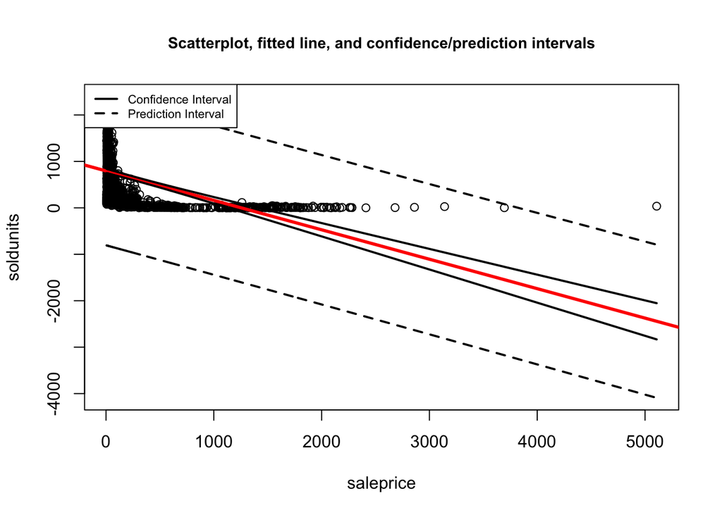

```r
#Fit simple linear regression
Selling <- lm(soldunits~saleprice, data = SALES)
#Visualize model
visualize.model(Selling)
```

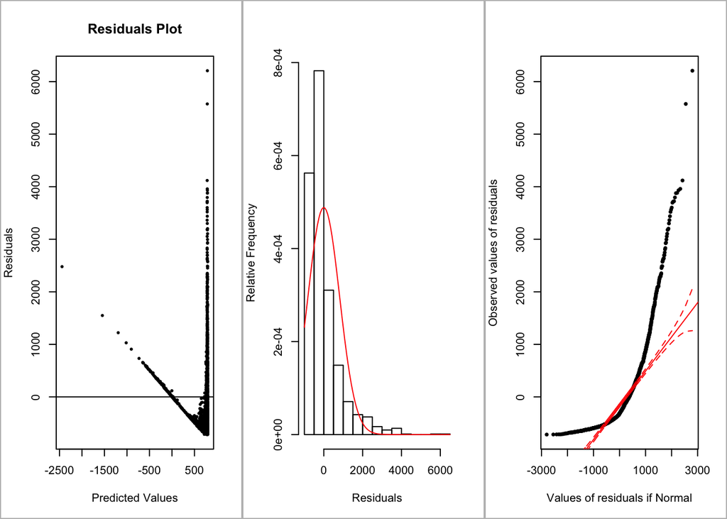

```r
#check.regression  (with extra argument tests=FALSE)
check.regression(Selling,tests=FALSE)
```

```r
#.165
```

**b.** Perhaps a better $y$ variable would be the number of items sold per viewer since we “know” that with more people watching, more items should be sold (the company can’t directly choose a value of viewership anyway). Make a scatterplot of the quantity `soldunits/viewers` versus `saleprice` to see that this is STILL not an appropriate relationship to model with a regression. Note: you can do this with `plot` by specifying `soldunits/viewers ~ saleprice` as the formula you are plotting. As with most scatterplots, you will need the `data=` argument as well. No response to write here, just R code.

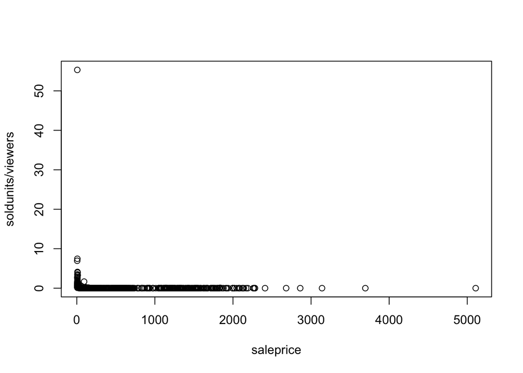

```r
#Scatterplot code
plot(soldunits/viewers~saleprice,data=SALES)
```

**c.** Modeling the logarithms of quantities often allows regression to be an appropriate model. The following code will add a variable called `y` to the dataframe defined as the log10 of soldunits/viewers and deletes the original columns. It then replaces the original values of `shows`, `duration`, `saleprice`, and `novelty` with their logarithms. *You will be predicting `y` from these variables for the remainder of this question*. Make a scatterplot of this $y$ variable versus `saleprice` (which is now the log10 of the original sale price) to see that the regression may now be a reasonable model. No response to write here, just R code.

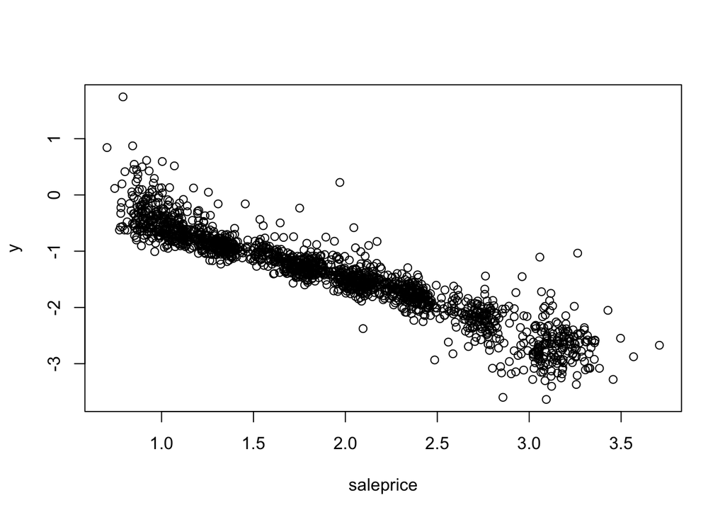

```r
#Uncomment the following lines and run them (you still need to write the code for plot)
SALES$y <- log10(SALES$soldunits/SALES$viewers)
SALES$soldunits <- NULL
SALES$viewers <- NULL
SALES$shows <- log10(SALES$shows)
SALES$duration <- log10(SALES$duration)
SALES$saleprice <- log10(SALES$saleprice)
SALES$novelty <- log10(SALES$novelty)

#Scatterplot of y vs. saleprice
plot(y~saleprice,data=SALES)
```

**d.** We are now ready to build a predictive model. Split the data into 65% training and 35% holdout. Be sure to `set.seed(320)` immediately before the `sample` command. No response to write here, just R code.

```r
#set seed
set.seed(320)
#determine rows for training set
train.rows <- sample(1:nrow(SALES),0.65*nrow(SALES))
TRAIN <- SALES[train.rows,]
HOLDOUT <- SALES[-train.rows,]
```

**e.** Let us consider regression model. At this point, you could run `build.model` on `TRAIN` to find a model with a reasonably small estimated generalization error. This takes a while (so don’t do it), but the result is a model with the formula `y~saleprice*(discount+novelty)+duration*novelty+week`. Use the code below to fit this model on `TRAIN`, then determine its RMSE on the holdout sample. Run `see.interactions` (with argument `cex=0.5` to make legends small). Discuss when the relationship between $y$ and `discount` is positive vs. negative and when the relationship is relatively strong vs. relatively weak.

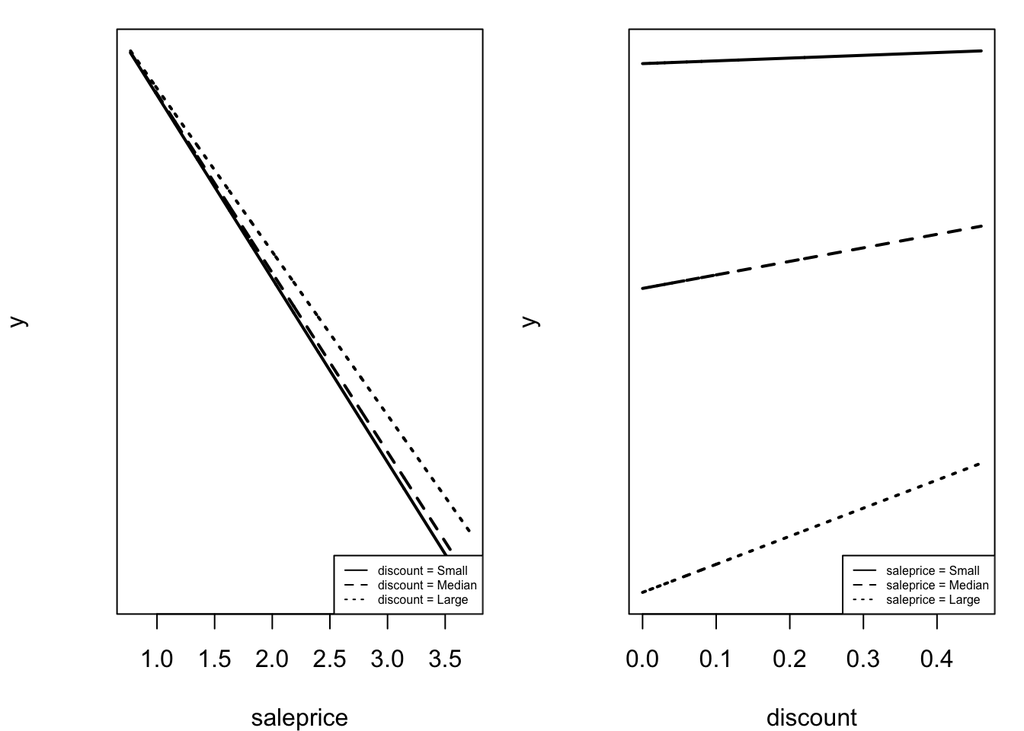

```
##
## Press [enter] to continue to see next set of interactions or q (then Enter) to quit
```

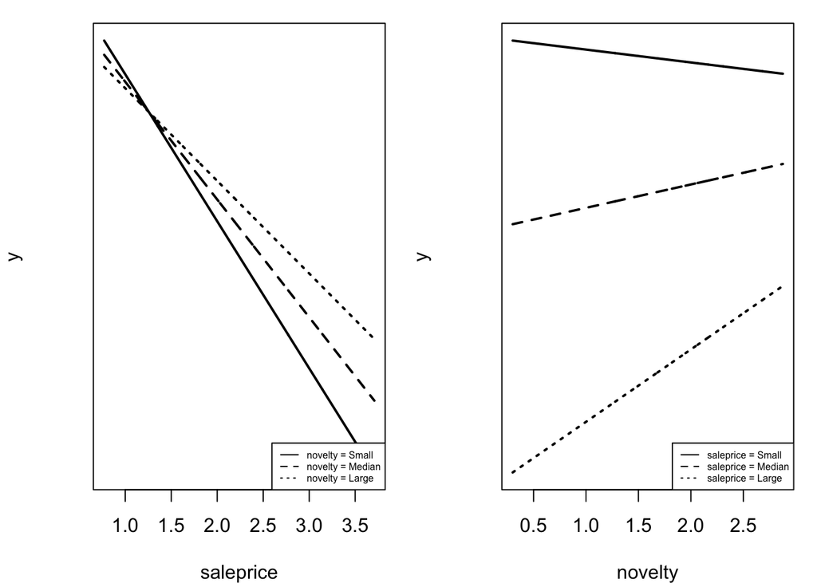

```
##
## Press [enter] to continue to see next set of interactions or q (then Enter) to quit
```

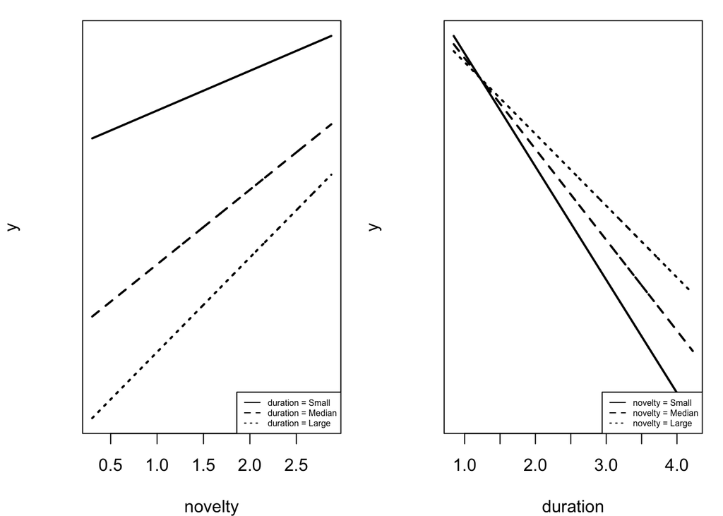

```r
M <- lm(y~saleprice*(discount+novelty)+duration*novelty+week,data=TRAIN)  #Uncomment and run
#Obtain generalization error on HOLDOUT
generalization.error(M,HOLDOUT)  #.172
## $RMSE.train
## [1] 0.1764619
##
## $RMSE.holdout
## [1] 0.1723611
#Run see.interactions with argument cex=0.5 to make legend small.
see.interactions(M, many=TRUE, cex=0.5)
```

**f.** Run `build.tree` to find a partition model (if you knit to Word, feel free to edit down the excessive number of lines in the CP table). Remember to build this on `TRAIN` to add the argument `seed=320` to that results are reproducible.

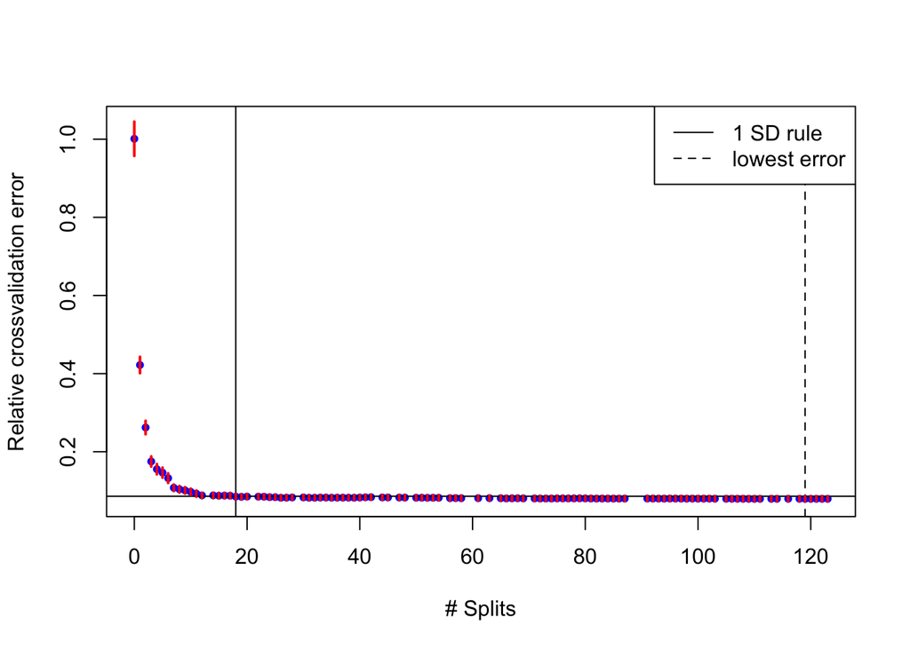

```r
#Run build.tree with argument seed=320
build.tree(y~.,data=TRAIN,seed=320)
##                CP nsplit  rel error     xerror        xstd
##      6.006227e-01      0 1.00000000 1.00100698 0.043928552
##      1.540349e-01      1 0.39937731 0.42204646 0.020976216
##      8.152599e-02      2 0.24534237 0.26203797 0.017295183
##      1.793862e-02      3 0.16381638 0.17511979 0.013061566
##      1.742204e-02      4 0.14587776 0.15543468 0.013289242
##      1.692775e-02      5 0.12845572 0.14659956 0.012956370
##      1.638979e-02      6 0.11152797 0.13244816 0.012471813
##      6.875601e-03      7 0.09513818 0.10783397 0.008563397
##      5.442191e-03      8 0.08826258 0.10402469 0.008566349
##      4.588483e-03      9 0.08282039 0.10113305 0.008421230
##      3.967623e-03     10 0.07823191 0.09753102 0.008211273
##      2.569544e-03     11 0.07426429 0.09291137 0.008014286
##      2.130834e-03     12 0.07169474 0.08834406 0.006738045
##      1.628480e-03     14 0.06743307 0.08837262 0.006907860
##      1.591371e-03     15 0.06580459 0.08747743 0.006798024
##      1.576721e-03     16 0.06421322 0.08785057 0.006805969
##      1.434066e-03     17 0.06263650 0.08745257 0.006793912
## 1SD* 1.336413e-03     18 0.06120244 0.08519736 0.006632278
##      1.111589e-03     19 0.05986602 0.08467248 0.006649158
##      1.070764e-03     20 0.05875443 0.08528938 0.006698276
##      1.045475e-03     22 0.05661291 0.08512600 0.006685898
##      9.701042e-04     23 0.05556743 0.08498605 0.006691755
##      9.559241e-04     24 0.05459733 0.08377880 0.006586015
##      7.369239e-04     25 0.05364140 0.08376100 0.006567614
##      6.884174e-04     26 0.05290448 0.08230619 0.006463223
##      6.767040e-04     27 0.05221606 0.08249503 0.006424889
##      6.749115e-04     28 0.05153936 0.08306118 0.006427031
##      5.919456e-04     30 0.05018954 0.08316814 0.006433696
##      5.787907e-04     31 0.04959759 0.08233314 0.006406167
##      5.519030e-04     32 0.04901880 0.08240475 0.006406023
##      5.207266e-04     33 0.04846690 0.08274286 0.006409690
##      4.970012e-04     34 0.04794617 0.08285783 0.006408659
##      4.969176e-04     35 0.04744917 0.08244723 0.006386547
##      4.922443e-04     36 0.04695225 0.08252195 0.006386147
##      4.847292e-04     37 0.04646001 0.08256897 0.006387925
##      4.488219e-04     38 0.04597528 0.08252951 0.006390946
##      4.203305e-04     39 0.04552645 0.08239546 0.006378372
##      3.950055e-04     40 0.04510612 0.08285839 0.006403894
##      3.949555e-04     41 0.04471112 0.08348232 0.006461144
##      3.766969e-04     42 0.04431616 0.08369441 0.006525582
##      3.725870e-04     44 0.04356277 0.08313701 0.006518805
##      3.687412e-04     45 0.04319018 0.08307879 0.006516595
##      3.528486e-04     47 0.04245270 0.08285370 0.006517765
##      3.485898e-04     48 0.04209985 0.08271231 0.006548799
##      3.299217e-04     50 0.04140267 0.08232578 0.006543161
##      3.206822e-04     51 0.04107275 0.08234214 0.006546895
##      3.189168e-04     52 0.04075207 0.08217053 0.006554636
##      3.161389e-04     53 0.04043315 0.08228178 0.006558473
##      2.893502e-04     54 0.04011701 0.08222245 0.006562307
##      2.733142e-04     56 0.03953831 0.08131264 0.006536842
##      2.725649e-04     57 0.03926500 0.08147949 0.006545138
##      2.632309e-04     58 0.03899243 0.08120479 0.006542140
##      2.606187e-04     61 0.03820274 0.08128674 0.006542046
##      2.550285e-04     63 0.03768150 0.08129046 0.006542096
##      2.051311e-04     65 0.03717145 0.08104621 0.006550212
##      1.830657e-04     66 0.03696631 0.08056387 0.006486655
##      1.818546e-04     67 0.03678325 0.08083492 0.006506054
##      1.809901e-04     68 0.03660139 0.08099486 0.006506169
##      1.692738e-04     69 0.03642040 0.08069791 0.006489693
##      1.671623e-04     71 0.03608186 0.08048510 0.006485504
##      1.552173e-04     72 0.03591469 0.08033038 0.006474221
##      1.535199e-04     73 0.03575948 0.08033868 0.006476356
##      1.479701e-04     74 0.03560596 0.08029240 0.006477403
##      1.472731e-04     75 0.03545799 0.08057988 0.006481836
##      1.418501e-04     76 0.03531071 0.08058895 0.006488526
##      1.414520e-04     77 0.03516886 0.08056952 0.006488637
##      1.319186e-04     78 0.03502741 0.08065962 0.006494240
##      1.294063e-04     79 0.03489549 0.08082234 0.006491858
##      1.185998e-04     80 0.03476609 0.08059644 0.006492729
##      1.086238e-04     81 0.03464749 0.08031463 0.006487542
##      1.082004e-04     82 0.03453886 0.08020463 0.006488961
##      1.076008e-04     83 0.03443066 0.08020463 0.006488961
##      1.062790e-04     84 0.03432306 0.08021231 0.006489114
##      1.028068e-04     85 0.03421678 0.08015515 0.006489538
##      1.025139e-04     86 0.03411398 0.08012578 0.006489480
##      9.542536e-05     87 0.03401146 0.08020860 0.006489746
##      9.409311e-05     91 0.03362976 0.08025466 0.006493857
##      9.318200e-05     92 0.03353567 0.08021318 0.006493946
##      9.200570e-05     93 0.03344249 0.08018759 0.006493653
##      7.931416e-05     94 0.03335048 0.08009434 0.006493754
##      7.824518e-05     95 0.03327117 0.08023484 0.006543564
##      7.615537e-05     96 0.03319292 0.08021308 0.006543583
##      7.085567e-05     97 0.03311677 0.08011088 0.006543684
##      6.929289e-05     98 0.03304591 0.08002503 0.006542950
##      6.926924e-05     99 0.03297662 0.08009782 0.006545672
##      6.873694e-05    100 0.03290735 0.08001494 0.006545571
##      6.546647e-05    101 0.03283861 0.07999798 0.006546354
##      6.385495e-05    102 0.03277314 0.08004267 0.006546402
##      6.277234e-05    103 0.03270929 0.07987887 0.006543660
##      5.785429e-05    105 0.03258374 0.07977392 0.006543219
##      5.476165e-05    106 0.03252589 0.07976739 0.006543121
##      5.094826e-05    107 0.03247113 0.07976339 0.006543113
##      5.094571e-05    108 0.03242018 0.07968491 0.006542263
##      4.731198e-05    109 0.03236923 0.07960877 0.006541056
##      4.372435e-05    110 0.03232192 0.07951748 0.006541093
##      4.042075e-05    111 0.03227820 0.07957694 0.006541074
##      3.811675e-05    113 0.03219736 0.07964968 0.006541039
##      3.735528e-05    114 0.03215924 0.07966299 0.006541589
##      3.635829e-05    116 0.03208453 0.07964924 0.006541718
##      3.550726e-05    118 0.03201181 0.07963245 0.006541847
## min* 2.410695e-05    119 0.03197631 0.07947048 0.006541988
##      1.888088e-05    120 0.03195220 0.07952382 0.006542659
##      1.782567e-05    121 0.03193332 0.07958846 0.006544247
##      1.464257e-05    122 0.03191549 0.07960250 0.006544100
##      0.000000e+00    123 0.03190085 0.07959025 0.006544139
##
## Suggested cp = 2.410695e-05 for the tree with the lowest generalization error ( 119 splits )
## Suggested cp = 0.001336413 for the simplest tree according to the one standard deviation rule ( 18 splits )
```

**f1:** What is the value of CP and the number of splits in the partition model with the lowest estimated generalization error?

**Response**: cp = 2.410695e-05; 119 splits

**f2:** What is the value of CP and the number of splits in the partition model selected by the one standard deviation rule?

**Response**: cp = 0.001336413; 18 splits

**f3:** Does the partition model show signs of being “overfit” as the number of rules added to it gets increasingly bigger? Why or why not?

**Response**: Yes, after we reach the lowest generalization error (0.07947048), that value progressively increases, which indicates that the model becomes overfit.

**f4:** Using the `cp` associated with the tree selected by the one standard deviation rule, fit the model using `rpart` (remember it is on `TRAIN`), then run `summarize.tree` and `generalization.error` to obtain the RMSE on the holdout sample.

```r
#TREE <- rpart(.....)
#Run summarize.tree
#Run generalization.error
TREE    <- rpart(y~.,data=TRAIN,cp=0.001336413)
summarize.tree(TREE)
## $rmse
## [1] 0.1992854
##
## $aic
## [1] -3414.412
##
## $importance
##    saleprice      novelty     duration        shows     discount shipdiscount         week
##   536.742651   336.090722   165.715561   151.347794    89.158387    79.185180     5.579581
##     weektype
##     0.141795
generalization.error(TREE, HOLDOUT) #.222
## $RMSE.train
## [1] 0.1976854
##
## $RMSE.holdout
## [1] 0.2227932
```

**f5:** Consider the variable importances. What is the most important predictor of $y$? Are promotions a relatively strong or relatively weak predictor of $y$? Does either promotion appear in any rules in the tree?

**Response**: saleprice. Promotions are near the bottom as far as most important predictors. Both promotions appear in the order of importance, but in the tree modeled itself, neither promotion appears.

**f6:** A product has `novelty=1.5` and is being planned to be shown for 630 minutes (`duration=2.8`) over 11 shows (`shows=1.04`) and sold at a price of $110 `saleprice=2.04` (with a 5% off promotion so `discount=0.05` but full-priced shipping so `shipdiscount=0`). Also, it is currently `week=220` and `weektype=Average`. FYI: since many quantities in the data are logarithms of the original values, the values of the variables vs. how they appear in the data are different (a duration of 630 minutes is log10(630)=2.8 in the data). Make a prediction for $y$ for this product by running `visualize.model` and following the resulting rules. Also report the number of items that live inside the partition this product is assigned.

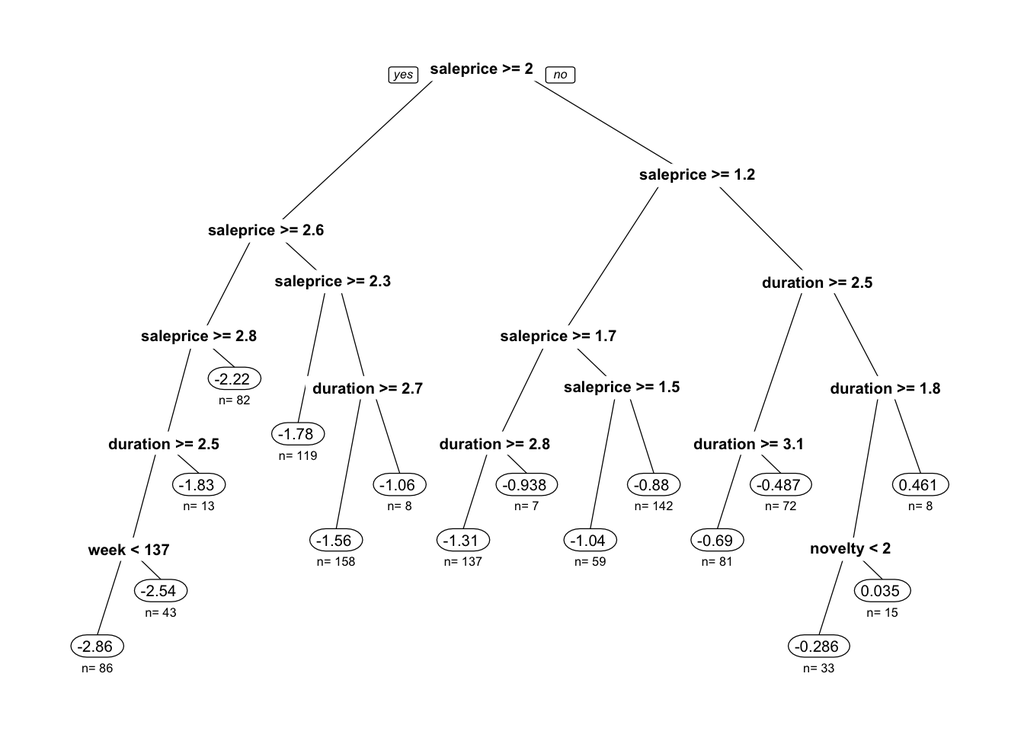

```r
#Run visualize.model
visualize.model(TREE)
```

**g.** Now fit a random forest model with 1000 trees. Remember to set the seed immediately before the `randomForest` command and to build the model on `TRAIN`. Find the generalization error on the holdout sample and run the following `visualize.relationship` command and describe the relationships between $y$ and the product discount for five (randomly picked) items.

```r
#set the seed
set.seed(320)
#fit the forest with ntree=1000
FOREST  <- randomForest(y~.,data=TRAIN,ntree=1000)
#obtain the generalization error
generalization.error(FOREST,HOLDOUT) #.170
## $RMSE.holdout
## [1] 0.1700237
#Uncomment the following line and run it
set.seed(320); visualize.relationship(FOREST,interest="discount",on=SALES,marginal=FALSE)
```

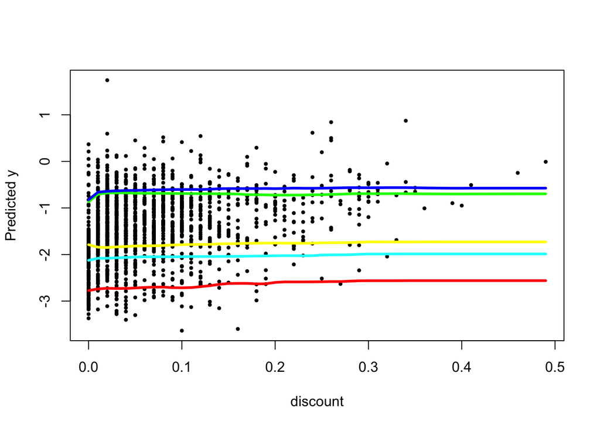

**h.** Which of the three models (regression, partition, or forest) end up having the lowest error on the holdout sample? Note: the regression model could be further improved by considering additional transformations of the original variables but we will not do that here.

#### Question 2:

Use `read.csv` to read in `HW12-reacquire.dat`, calling it `REACQUIRE`. In this dataset, the goal is to predict whether customers who have previously churned are reacquired (`Reacquire`) after they have been given a special offer. This is the same data used in Activity11. Split the data into 60% training and 40% holdout. Be sure to `set.seed(320)` immediately before the `sample` command.

```r
REACQUIRE <- read.csv("HW12-reacquire.dat")  #Uncomment and run
#set seed
#obtain training rows
#define training set
#define holdout sample
set.seed(320)
train.rows2 <- sample(1:nrow(REACQUIRE),0.60*nrow(REACQUIRE))
TRAIN2 <- REACQUIRE[train.rows2,]
HOLDOUT2 <- REACQUIRE[-train.rows2,]
```

**a.** Building a logistic regression can be time consuming since logistic regression takes a while. In Activity 11 you found a reasonable model to be `Reacquire~Lifetime+Lapse+Offer*Age`. Fit this model on `TRAIN`, then report the misclassification rate on `HOLDOUT` as well as the number of customers that the model predicts are NOT reacquired (`Predicted No`) but who in actually are (`Actual Yes`).

```r
M <- glm(Reacquire~Lifetime+Lapse+Offer*Age,data=TRAIN2,family=binomial)  #Uncomment and run
#Obtain generalization error
generalization.error(M,HOLDOUT2)
## $Confusion.Matrices
## $Confusion.Matrices$Training
##            Predicted No Predicted Yes Total
## Actual No           114            17   131
## Actual Yes           17           152   169
## Total               131           169   300
##
## $Confusion.Matrices$Holdout
##            Predicted No Predicted Yes Total
## Actual No            64            10    74
## Actual Yes           15           111   126
## Total                79           121   200
##
##
## $Misclassification.Rates
## $Misclassification.Rates$Training
## [1] 0.1133333
##
## $Misclassification.Rates$Holdout
## [1] 0.125
```

**Response:** Misclassification=0.125; 15

**b.** Run `build.tree` to find a partition model predicting `Reacquire`. Remember to build this on `TRAIN` and to add the argument `seed=320` so that results are reproducible. Choose the value of `cp` to be the one that corresponds to the model selected by the one standard deviation rule, then fit the tree using `rpart`.

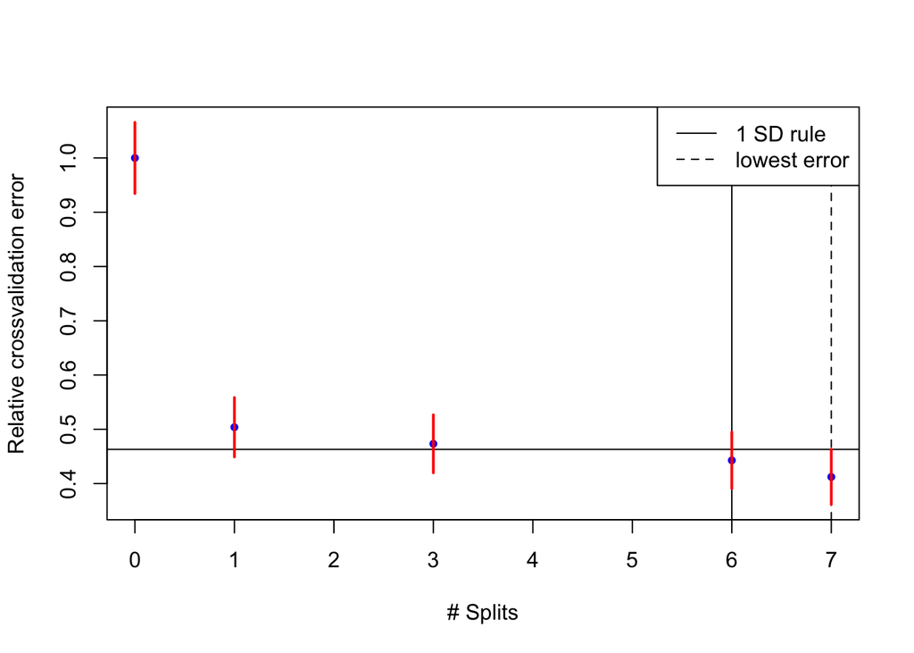

```r
#run build.tree
build.tree(Reacquire~.,data=TRAIN2,seed=320)
##              CP nsplit rel error    xerror       xstd
##      0.58015267      0 1.0000000 1.0000000 0.06557633
##      0.04961832      1 0.4198473 0.5038168 0.05477066
##      0.03435115      3 0.3206107 0.4732824 0.05353680
## 1SD* 0.03053435      6 0.2137405 0.4427481 0.05221434
## min* 0.00000000      7 0.1832061 0.4122137 0.05079635
##
## Suggested cp = 0 for the tree with the lowest generalization error ( 7 splits )
## Suggested cp = 0.03053435 for the simplest tree according to the one standard deviation rule ( 6 splits )
```

```r
#fit the tree model using the relevant cp
TREE2   <- rpart(Reacquire~.,data=TRAIN2,cp=0.03053435)
summarize.tree(TREE2)
## $rmse
## [1] 1.784055
##
## $aic
## [1] 353.2246
##
## $importance
##    Lifetime       Lapse         Age       Offer PriceChange
##   77.433589   26.150411    8.919078    7.855349    3.423733
```

**b1:** Report the misclassification rate on `HOLDOUT` as well as the number of customers that the model predicts are NOT reacquired (`Predicted No`) but who in actually are (`Actual Yes`).

```r
#Obtain generalization error
generalization.error(TREE2, HOLDOUT2)
## $CM.train
##            Predicted No Predicted Yes Total
## Actual No           124             7   131
## Actual Yes           22           147   169
## Total               146           154   300
##
## $misclass.train
## [1] 0.09666667
##
## $CM.holdout
##            Predicted No Predicted Yes Total
## Actual No            61            13    74
## Actual Yes           25           101   126
## Total                86           114   200
##
## $misclass.holdout
## [1] 0.19
```

**Response:** Misclassification=0.19; 25

**b2:** If a male customer age 35 had `Lifetime=300`, `Offer=20`, `Lapse=50`, and the price of the item the customer used to buy has not changed, what does the model predict for his probability of reacquisition? Note: run `visualize.model` and base your answer on the resulting plot.

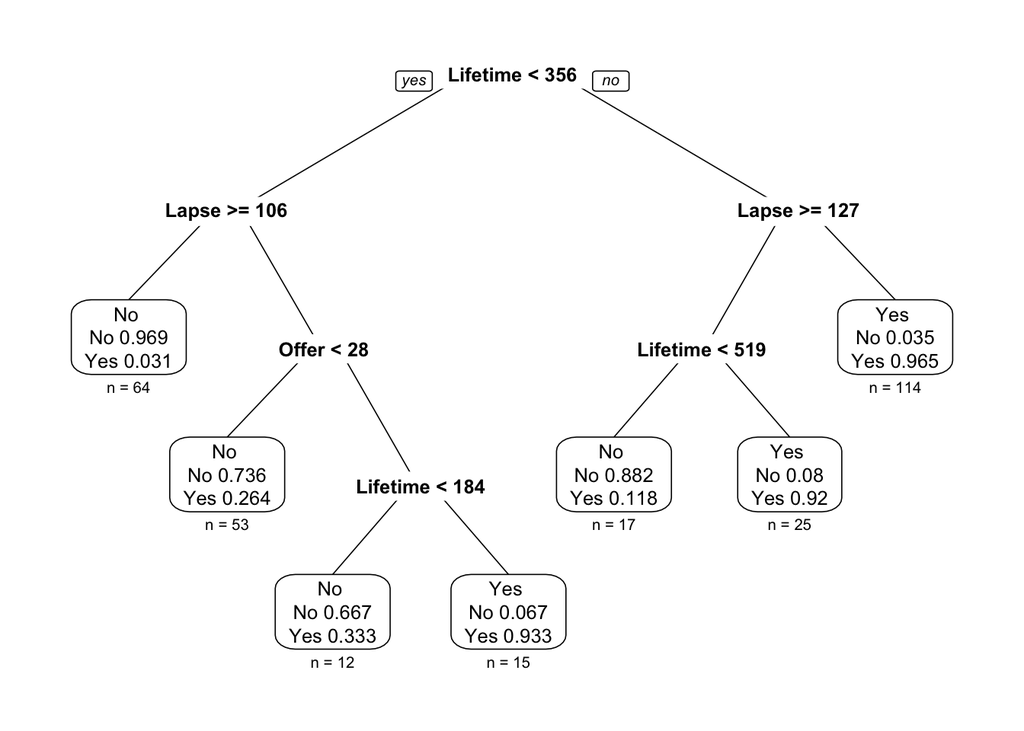

```r
#visualize the tree
visualize.model(TREE2)
```

**Response:** 0.264; n=53

**c.** Now fit a random forest model with 1000 trees. Remember to set the seed immediately before the `randomForest` command and to build the model on `TRAIN`. Report the misclassification rate on `HOLDOUT` as well as the number of customers that the model predicts are NOT reacquired (`Predicted No`) but who in actually are (`Actual Yes`).

```r
#set the seed to 320
set.seed(320)
#fit the forest
FOREST2 <- randomForest(Reacquire~.,data=TRAIN2,ntree=1000)
#obtain the generalization error of the forest
generalization.error(FOREST2,HOLDOUT2)
## $CM.holdout
##            Predicted No Predicted Yes Total
## Actual No            58            16    74
## Actual Yes           17           109   126
## Total                75           125   200
##
## $misclass.holdout
## [1] 0.165
```

**Response**: Misclassification=0.165; 17

**d.** Which model (regression, partition, or forest) happens to perform the best on this holdout sample (the results may of course vary given a different set of “new” data)?

**Response**: Logistic regression seems to perform the best here as per lowest misclassification rate.